# CHAPTER 4

# DATA ANALYSIS AND RESULTS

## Data Preparation

Before conducting the Factor analysis, we will perform several data preparation steps. This included data cleaning, missing value imputation, and variable transformation. Additionally, we will conduct a preliminary exploratory data analysis to gain insights into the distribution and characteristics of the variables.

To understand the dataset and have a feel of the data, let’s look at the first ten observations of the data.

```r
library(psych)
pro_data<- read.csv("Depression.csv", header = T, sep = ",")
df<- as.data.frame(pro_data)
knitr::kable(head(pro_data, 10), "latex", booktabs=TRUE, longtable= T,
             caption = "FIRST TEN OBSERVATION")
```

[output not shown]

We will majorly work with variables X1-X9 which represents the observed variables in our FA model.

Therefore, we will ignore the first 3 columns of our data set that is, Index, Gender and Age columns

```r
Depr<-df %>%
  select(-(Index))

col_rem<-c("Gender", "Index")
Depr<-pro_data %>%
  select(-one_of(col_rem))

#removing the index,gender,age columns

cl_rm<-c("Index","Gender", "Age")
new_pro_data<-pro_data %>%
  select(-one_of(cl_rm))
View(new_pro_data)
```

Checking for missing values is crucial in Factor Analysis as missing data can potentially introduce bias and affect the accuracy of the results. Missing values can lead to a loss of information and may impact the estimation of Factor loadings and the overall interpretation of the factors.

```r
#identifying missing values
sum(is.na(new_pro_data))
```

```
## [1] 0
```

As seen above, our data has no missing values therefore we can proceed with our analysis with reduced risk of biased findings and providing a more accurate understanding of the underlying factors contributing to the phenomenon under investigation.

## Descriptive Statistics

We begin by presenting descriptive statistics of the variables included in the analysis. This includes measures of central tendency (mean, median) and measures of variability (standard deviation, range). By understanding this, will help us with an overview of our variables that we shall use in building our Factor model. The measures of central tendencies can only be computed for the numerical variables thus we shall perform the descriptive statistics on Age and our variables X1- X9

```r
psych::describe(Depr)
```

```
##     vars   n  mean   sd median trimmed  mad min max range  skew kurtosis   se
## Age    1 247 26.35 6.78     24   26.15 5.93  12  40    28  0.31    -0.84 0.43
## x1     2 247  1.70 1.02      1    1.75 1.48   0   3     3  0.04    -1.31 0.07
## x2     3 247  1.74 1.06      2    1.79 1.48   0   3     3 -0.10    -1.31 0.07
## x3     4 247  1.73 1.13      2    1.79 1.48   0   3     3 -0.18    -1.43 0.07
## x4     5 247  2.02 1.04      2    2.13 1.48   0   3     3 -0.51    -1.11 0.07
## x5     6 247  1.34 1.12      1    1.30 1.48   0   3     3  0.27    -1.31 0.07
## x6     7 247  1.62 1.13      1    1.64 1.48   0   3     3 -0.01    -1.43 0.07
## x7     8 247  1.37 1.10      1    1.34 1.48   0   3     3  0.23    -1.26 0.07
## x8     9 247  1.09 0.98      1    0.99 1.48   0   3     3  0.52    -0.76 0.06
## x9    10 247  0.95 1.10      1    0.82 1.48   0   3     3  0.83    -0.69 0.07
```

Let’s now take a look at how our respondents are distributed in terms of ages of either gender.

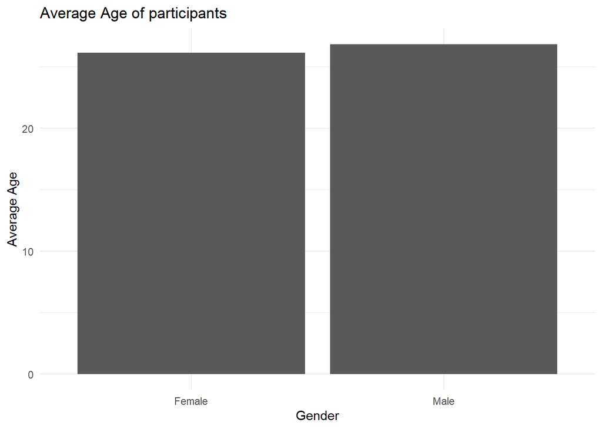

```r
pro_data$Gender[pro_data$Gender==1]<-"Male"
pro_data$Gender[pro_data$Gender==2]<-"Female"

by_gender<-pro_data %>%
  group_by(Gender) %>%
  summarize(mean_age=mean(Age))

ggplot(by_gender,aes(x=Gender,y=mean_age),fill=Gender)+
  geom_col()+
  labs(x="Gender",y="Average Age", ylim=c(0, 30),title = "Average Age of participants")+
  theme_minimal()
```

**Checking normality assumptions**

Factor Analysis models are based on the covariances among variances, they are susceptible to the effects of violations to the assumption of normality, which can strongly affect covariances.(Hartman, 2018). To check this assumption, we will examine our variables to check if there are any serious deviations from normality using histograms and Royston’s normality techniques.

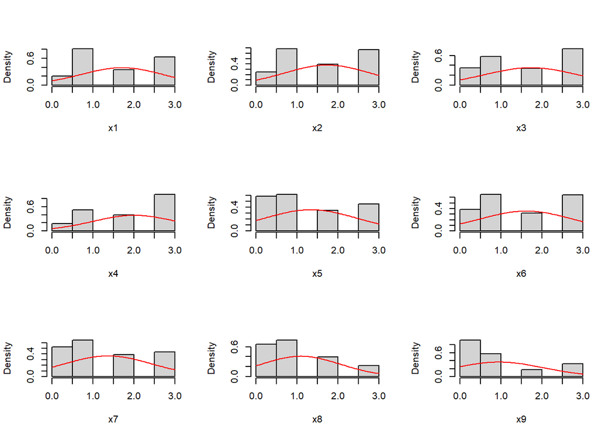

```r
library(MVN)
ind_var <- df[,paste("x", 1:9, sep="")]
normality1<-mvn(data=ind_var, mvnTest="royston",univariatePlot="histogram")
```

**Data Standardization**

We shall starndardize our variables using Zscore scaling. Z-score scaling transforms our variables to have a mean of zero and a standard deviation of one. This normalization process allows for a more meaningful comparison of variables with different scales and units.

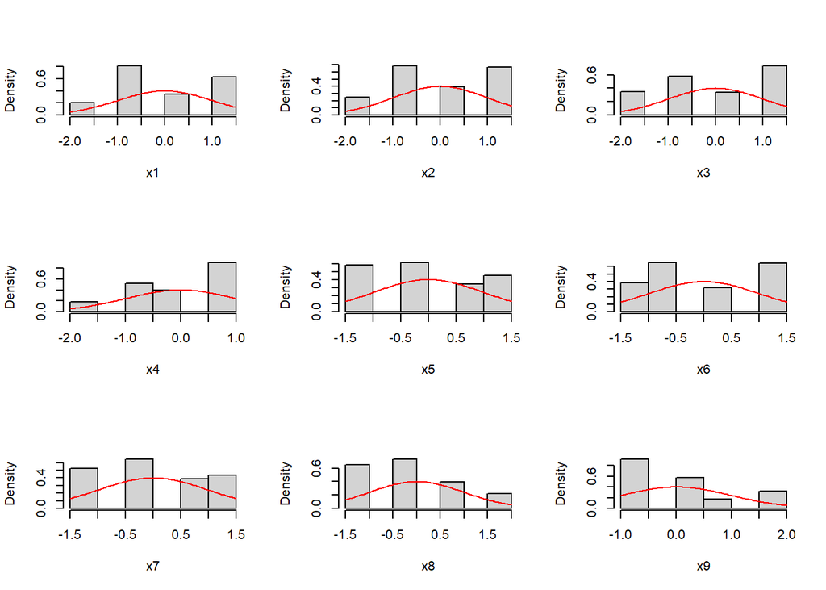

```r
Zscore<-scale(new_pro_data)
View(Zscore)
normality2<-mvn(data=Zscore, mvnTest="royston",univariatePlot="histogram")
```

```r
normality2
```

```
## $multivariateNormality
##      Test        H       p value MVN
## 1 Royston 594.5605 5.030746e-122  NO
##
## $univariateNormality
##               Test  Variable Statistic   p value Normality
## 1 Anderson-Darling    x1       17.5696  <0.001      NO
## 2 Anderson-Darling    x2       15.1837  <0.001      NO
## 3 Anderson-Darling    x3       15.9452  <0.001      NO
## 4 Anderson-Darling    x4       19.7831  <0.001      NO
## 5 Anderson-Darling    x5       13.7992  <0.001      NO
## 6 Anderson-Darling    x6       15.1708  <0.001      NO
## 7 Anderson-Darling    x7       12.8536  <0.001      NO
## 8 Anderson-Darling    x8       14.0168  <0.001      NO
## 9 Anderson-Darling    x9       22.1000  <0.001      NO
##
## $Descriptives
##      n          Mean Std.Dev      Median        Min       Max       25th
## x1 247 -3.731060e-19       1 -0.68864342 -1.6662005 1.2664707 -0.6886434
## x2 247 -9.116077e-18       1  0.24939751 -1.6460236 1.1971080 -0.6983130
## x3 247  4.613083e-17       1  0.23562467 -1.5279903 1.1174321 -0.6461828
## x4 247 -1.386534e-16       1 -0.01563443 -1.9464859 0.9497913 -0.9810602
## x5 247  1.803638e-18       1 -0.29880798 -1.1880317 1.4796395 -1.1880317
## x6 247 -3.208229e-17       1 -0.54602925 -1.4333268 1.2285658 -0.5460292
## x7 247 -7.647938e-17       1 -0.33616507 -1.2486131 1.4887310 -1.2486131
## x8 247 -8.811623e-17       1 -0.09530057 -1.1187458 1.9515899 -1.1187458
## x9 247  2.173672e-17       1  0.04433371 -0.8682019 1.8694049 -0.8682019
##         75th         Skew   Kurtosis
## x1 1.2664707  0.043946482 -1.3143077
## x2 1.1971080 -0.104299967 -1.3142945
## x3 1.1174321 -0.182340330 -1.4259668
## x4 0.9497913 -0.513021751 -1.1123751
## x5 0.5904158  0.273278054 -1.3089854
## x6 1.2285658 -0.006827855 -1.4277033
## x7 0.5762830  0.233965842 -1.2609069
## x8 0.9281446  0.517303404 -0.7596885
## x9 0.5006015  0.833984627 -0.6853221
```

## Factor Analysis Model

We shall apply FA model to identify the number of latent factors that infer the presence and severity of depression amongst the Kenyan youth population. We shall use Principal Component Analysis (PCA), to extract the factors. The number of factors will be determined based on eigenvalues, scree plot examination.

Before proceeding with factors extaration, let’s perform Bartlett’s test of sphericity to determine whether a correlation matrix of our variables(X1- X9) is significantly different from an identity matrix, indicating the appropriateness of conducting a Factor analysis. The Barlett’s test assesses whether our variables, X1- X9, are interrelated enough to justify the extraction of common factors.

The test evaluates the null hypothesis that the correlation matrix is an identity matrix, implying that variables are uncorrelated and factor analysis is not suitable. The alternative hypothesis suggests that the correlation matrix is not an identity matrix, indicating sufficient intercorrelations among variables for factor analysis.

```r
library(REdaS)
bart_spher(new_pro_data)
```

```
##  Bartlett's Test of Sphericity
##
## Call: bart_spher(x = new_pro_data)
##
##      X2 = 844.617
##      df = 36
## p-value < 2.22e-16
```

From the results the test produces a p value of less than 0.05 hence our variables, X1- X9, are interrelated enough to justify the extraction of common factors.

### Principal Components solution

One of the methods used in factor extraction is Principal components solution. PCA reduces the dimensionality of the dataset by transforming the original variables into a new set of uncorrelated variables called principal components. In order to come up with a unique solution we shall perform our analysis on our standardized variables.

```r
data_pca <-prcomp(new_pro_data, retx=TRUE, center=FALSE, scale=TRUE)
summary(data_pca)
```

```
## Importance of components:
##                           PC1     PC2     PC3     PC4     PC5     PC6     PC7
## Standard deviation     2.7049 0.60143 0.57790 0.50191 0.46854 0.41118 0.39716
## Proportion of Variance 0.8129 0.04019 0.03711 0.02799 0.02439 0.01879 0.01753
## Cumulative Proportion  0.8129 0.85310 0.89021 0.91820 0.94259 0.96138 0.97891
##                            PC8     PC9
## Standard deviation     0.33520 0.27836
## Proportion of Variance 0.01248 0.00861
## Cumulative Proportion  0.99139 1.00000
```

For a better view this, let’s visualize this result on scree plot.

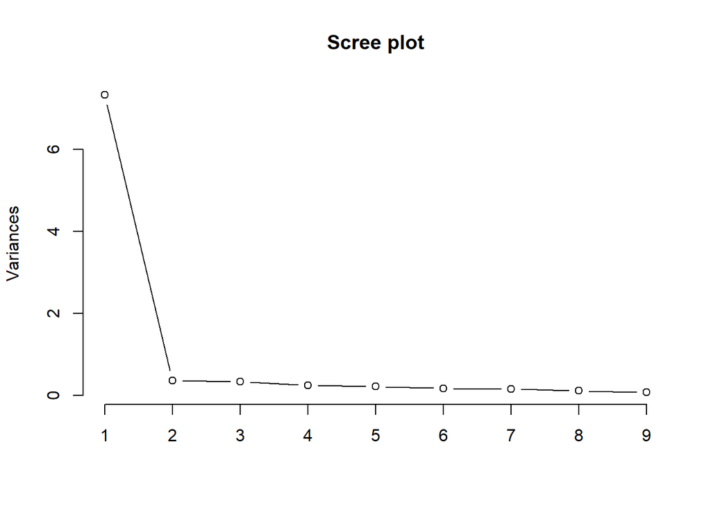

```r
screeplot(data_pca,type='l', main = "Scree plot")
```

From the cumulative proportion and scree plot we can conclude that the first two components,PC1 and PC2, explains nearly 86% of the total variance. This means that the first two principal components can accurately represent our data.

**Loadings matrix**

```r
knitr::kable(data_pca$rotation, booktabs=TRUE,  longtable=T,caption = "loadings",) %>%
  kableExtra::kable_styling(full_width = FALSE)
```

loadings

|  | PC1 | PC2 | PC3 | PC4 | PC5 | PC6 | PC7 | PC8 | PC9 |
| --- | --- | --- | --- | --- | --- | --- | --- | --- | --- |
| x1 | -0.3313213 | 0.2405843 | -0.1518165 | 0.6489980 | -0.3192214 | 0.2295026 | 0.3206828 | 0.3595045 | 0.0380008 |
| x2 | -0.3507561 | -0.0358480 | -0.1394410 | 0.1908451 | -0.0046149 | 0.1136319 | -0.1482687 | -0.7039229 | 0.5379544 |
| x3 | -0.3373868 | 0.2173807 | -0.3078203 | -0.0497565 | 0.0880032 | -0.7466463 | -0.2636625 | 0.2746371 | 0.1775330 |
| x4 | -0.3525266 | 0.1940792 | -0.1421475 | 0.0348539 | 0.0429909 | -0.0692589 | 0.0084622 | -0.4186717 | -0.7966398 |
| x5 | -0.3285995 | 0.1422229 | 0.0905325 | -0.6147897 | -0.6769830 | 0.1452959 | 0.0024065 | 0.0473857 | 0.0629644 |
| x6 | -0.3413658 | -0.0916276 | -0.0927938 | -0.0710164 | 0.3266536 | 0.5276328 | -0.6011698 | 0.3322899 | -0.0670755 |
| x7 | -0.3369660 | 0.0080996 | -0.1093994 | -0.3594906 | 0.5221837 | 0.1136792 | 0.6588999 | 0.0752952 | 0.1406034 |
| x8 | -0.3106558 | 0.1558649 | 0.9012510 | 0.1341881 | 0.1544741 | -0.1477488 | -0.0436953 | 0.0146602 | 0.0335123 |
| x9 | -0.3074577 | -0.8960639 | 0.0389900 | 0.0918673 | -0.1641254 | -0.1946249 | 0.0901117 | 0.0774030 | -0.1168421 |

The Loading can be interpreted as the correlation of each item with the component. It represents the contribution of each variable to each PC. Positive or negative values indicate the direction and strength of the relationship. Variables with higher absolute loading values have a more significant impact on the corresponding PC. Each item has a loading corresponding to each of the 9 components. For example, variable X1, is correlated -0.33 with the first principal component, 0.24 with the second component and so on. The square of each loading represents the proportion of variance explained by a particular component. Summing the squared loadings across the principal components (columns) gives you the communality estimates for each item, and summing each squared loading down the items (rows) gives you the eigenvalue for each component.

**Chosing the number of components**

Since the goal of running a PCA is to reduce our set of variables down one of the criterion discused in our methodology is to choose components that have eigenvalues greater than 1.

```r
varcov<- cor(new_pro_data)
eigen(varcov)$values
```

```
## [1] 4.5011459 0.8194965 0.7756848 0.7000963 0.5371757 0.4980671 0.4349160
## [8] 0.4243792 0.3090386
```

From the results and confirmed by the screeplot above it confirms the first principal component can sufficiently represent our data.

To confirm this lets’s run a chi-square test to confirm if one factor model sufficiently represents our data.

```r
R<-cov(new_pro_data)
factanal(covmat=R,factors=1,method="mle",n.obs=247,rotation = "none")
```

```
##
## Call:
## factanal(factors = 1, covmat = R, n.obs = 247, rotation = "none",     method = "mle")
##
## Uniquenesses:
##    x1    x2    x3    x4    x5    x6    x7    x8    x9
## 0.748 0.377 0.593 0.391 0.590 0.500 0.470 0.776 0.575
##
## Loadings:
##    Factor1
## x1 0.502
## x2 0.789
## x3 0.638
## x4 0.780
## x5 0.640
## x6 0.707
## x7 0.728
## x8 0.473
## x9 0.652
##
##                Factor1
## SS loadings      3.980
## Proportion Var   0.442
##
## Test of the hypothesis that 1 factor is sufficient.
## The chi square statistic is 44.51 on 27 degrees of freedom.
## The p-value is 0.0183
```

From the results the p- value is 0.0183 suggesting that the model is a poor fit. ~

We therefore proceed to test if 2 factors is suffiient to represent our data.

```r
factanal(covmat=R,factors=2,method="mle",n.obs=247,rotation = "none")
```

```
##
## Call:
## factanal(factors = 2, covmat = R, n.obs = 247, rotation = "none",     method = "mle")
##
## Uniquenesses:
##    x1    x2    x3    x4    x5    x6    x7    x8    x9
## 0.750 0.366 0.564 0.261 0.596 0.478 0.477 0.773 0.429
##
## Loadings:
##    Factor1 Factor2
## x1  0.500
## x2  0.788   0.111
## x3  0.641  -0.160
## x4  0.813  -0.280
## x5  0.635
## x6  0.701   0.178
## x7  0.723
## x8  0.467
## x9  0.661   0.365
##
##                Factor1 Factor2
## SS loadings      4.015   0.292
## Proportion Var   0.446   0.032
## Cumulative Var   0.446   0.478
##
## Test of the hypothesis that 2 factors are sufficient.
## The chi square statistic is 21.96 on 19 degrees of freedom.
## The p-value is 0.286
```

The p-value is 0.286 sugesting that the two factor model is a good fit for our data.

If we repeat the test with three factors upto 5 we get a good fit. The goal Principal components solution is to reduce the number of factors as small as possible but still sufficiently representing our data.

## Factor Rotation

After deciding on the number of factors to extract and with analysis model to use, the next step is to interpret the factor loadings. Factor rotations help us interpret factor loadings. The goal of factor rotation is to improve the interpretability of the factor solution by reaching simple structure.

Without rotation, the first factor is the most general factor onto which most items load and explains the largest amount of variance.

```r
fa <- principal(new_pro_data, nfactors=2, rotate="none")

fa$loadings
```

```
##
## Loadings:
##    PC1    PC2
## x1  0.561 -0.305
## x2  0.811 -0.117
## x3  0.683 -0.349
## x4  0.803 -0.167
## x5  0.698  0.156
## x6  0.746
## x7  0.764
## x8  0.542  0.722
## x9  0.703  0.115
##
##                  PC1   PC2
## SS loadings    4.501 0.819
## Proportion Var 0.500 0.091
## Cumulative Var 0.500 0.591
```

For our analysis we shall use Orthogonal rotation assumes that the factors are not correlated. The benefit of doing varimax method which is an orthogonal rotation is that loadings are simple correlations of items with factors, and standardized solutions can estimate unique contribution of each factor.

```r
fa <- principal(new_pro_data, nfactors=2, rotate="varimax")
fa$loadings
```

```
##
## Loadings:
##    RC1   RC2
## x1 0.635
## x2 0.734 0.364
## x3 0.761 0.101
## x4 0.755 0.319
## x5 0.486 0.525
## x6 0.577 0.478
## x7 0.623 0.443
## x8       0.902
## x9 0.513 0.494
##
##                  RC1   RC2
## SS loadings    3.314 2.007
## Proportion Var 0.368 0.223
## Cumulative Var 0.368 0.591
```

We can visualize model for a better view

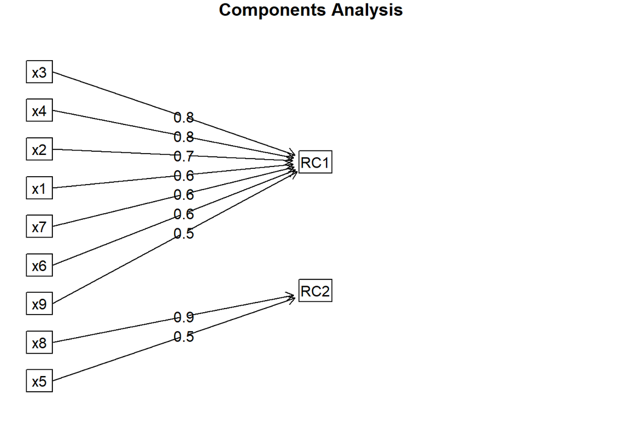

```r
fa.diagram(fa)
```

From the loadings matrix, it’s evident that variables X1, X2, X3, X4, X6, X7 and X9 has a higher loadings on the Factor 1 while variables X5 and X8 has higher loadings on Factor 2.